# Coursera Practical Machine Learning Assignment

Taeyoung Ahn

2018-05-06

# 1. Introduction

Using devices such as Jawbone Up, Nike FuelBand, and Fitbit it is now possible to collect a large amount of data about personal activity relatively inexpensively. These type of devices are part of the quantified self movement - a group of enthusiasts who take measurements about themselves regularly to improve their health, to find patterns in their behavior, or because they are tech geeks. One thing that people regularly do is quantify how much of a particular activity they do, but they rarely quantify how well they do it. In this project, your goal will be to use data from accelerometers on the belt, forearm, arm, and dumbell of 6 participants. They were asked to perform barbell lifts correctly and incorrectly in 5 different ways. More information is available from the website here: http://groupware.les.inf.puc-rio.br/har (see the section on the Weight Lifting Exercise Dataset).

# 2. Data Source

The training data for this project are available here:

https://d396qusza40orc.cloudfront.net/predmachlearn/pml-training.csv

The test data are available here:

https://d396qusza40orc.cloudfront.net/predmachlearn/pml-testing.csv

The data for this project come from this source: http://groupware.les.inf.puc-rio.br/har. If you use the document you create for this class for any purpose please cite them as they have been very generous in allowing their data to be used for this kind of assignment.

# 3. Loading and inspecting data

## 3.1. Loading data:

```r
rm(list=ls())
training <- read.csv("https://d396qusza40orc.cloudfront.net/predmachlearn/pml-training.csv")
testing <- read.csv("https://d396qusza40orc.cloudfront.net/predmachlearn/pml-testing.csv")
```

## 3.2. Inspecting Data:

```r
dim(training);dim(testing)
```

```
## [1] 19622   160
```

```
## [1]  20 160
```

There are 19622 rows and 160 columns in the training data, 20 rows and 160 columns in the testing data.

```r
str(training)
```

```
## 'data.frame':    19622 obs. of  160 variables:
##  $ X                       : int  1 2 3 4 5 6 7 8 9 10 ...
##  $ user_name               : Factor w/ 6 levels "adelmo","carlitos",..: 2 2 2 2 2 2 2 2 2 2 ...
##  $ raw_timestamp_part_1    : int  1323084231 1323084231 1323084231 1323084232 1323084232 1323084232 1323084232 1323084232 1323084232 1323084232 ...
##  $ raw_timestamp_part_2    : int  788290 808298 820366 120339 196328 304277 368296 440390 484323 484434 ...
##  $ cvtd_timestamp          : Factor w/ 20 levels "02/12/2011 13:32",..: 9 9 9 9 9 9 9 9 9 9 ...
##  $ new_window              : Factor w/ 2 levels "no","yes": 1 1 1 1 1 1 1 1 1 1 ...
##  $ num_window              : int  11 11 11 12 12 12 12 12 12 12 ...
##  $ roll_belt               : num  1.41 1.41 1.42 1.48 1.48 1.45 1.42 1.42 1.43 1.45 ...
##  $ pitch_belt              : num  8.07 8.07 8.07 8.05 8.07 8.06 8.09 8.13 8.16 8.17 ...
##  $ yaw_belt                : num  -94.4 -94.4 -94.4 -94.4 -94.4 -94.4 -94.4 -94.4 -94.4 -94.4 ...
##  $ total_accel_belt        : int  3 3 3 3 3 3 3 3 3 3 ...
##  $ kurtosis_roll_belt      : Factor w/ 397 levels "","-0.016850",..: 1 1 1 1 1 1 1 1 1 1 ...
##  $ kurtosis_picth_belt     : Factor w/ 317 levels "","-0.021887",..: 1 1 1 1 1 1 1 1 1 1 ...
##  $ kurtosis_yaw_belt       : Factor w/ 2 levels "","#DIV/0!": 1 1 1 1 1 1 1 1 1 1 ...
```

[output cut: 86 more lines]

# 4. Cleaning Data

## 4.1. Removing redundant columns

We have a lot of columns(features) in the testing set which are completely redundant, as they are consisted of all NA values. We want to disregard these features from both data sets. We also want to disregard features such as X, user_name, raw_timestamp, new_window, num_window as they do not contribute to the prediction of classes.

```r
redundant_features <- colSums(testing[,c(7:160)], na.rm = TRUE)==0
redundant_features <- names(redundant_features[redundant_features==TRUE])
testing <- testing[,-which(names(testing) %in% c(redundant_features, "X","user_name","raw_timestamp_part_1","raw_timestamp_part_2",
                                                 "cvtd_timestamp","new_window","num_window"))]
training <- training[,-which(names(training) %in% c(redundant_features, "X","user_name","raw_timestamp_part_1","raw_timestamp_part_2",
                                                 "cvtd_timestamp","new_window","num_window"))]
# Checking if all features are set
str(testing)
```

```
## 'data.frame':    20 obs. of  53 variables:
##  $ roll_belt           : num  123 1.02 0.87 125 1.35 -5.92 1.2 0.43 0.93 114 ...
##  $ pitch_belt          : num  27 4.87 1.82 -41.6 3.33 1.59 4.44 4.15 6.72 22.4 ...
##  $ yaw_belt            : num  -4.75 -88.9 -88.5 162 -88.6 -87.7 -87.3 -88.5 -93.7 -13.1 ...
##  $ total_accel_belt    : int  20 4 5 17 3 4 4 4 4 18 ...
##  $ gyros_belt_x        : num  -0.5 -0.06 0.05 0.11 0.03 0.1 -0.06 -0.18 0.1 0.14 ...
##  $ gyros_belt_y        : num  -0.02 -0.02 0.02 0.11 0.02 0.05 0 -0.02 0 0.11 ...
##  $ gyros_belt_z        : num  -0.46 -0.07 0.03 -0.16 0 -0.13 0 -0.03 -0.02 -0.16 ...
##  $ accel_belt_x        : int  -38 -13 1 46 -8 -11 -14 -10 -15 -25 ...
##  $ accel_belt_y        : int  69 11 -1 45 4 -16 2 -2 1 63 ...
##  $ accel_belt_z        : int  -179 39 49 -156 27 38 35 42 32 -158 ...
##  $ magnet_belt_x       : int  -13 43 29 169 33 31 50 39 -6 10 ...
##  $ magnet_belt_y       : int  581 636 631 608 566 638 622 635 600 601 ...
##  $ magnet_belt_z       : int  -382 -309 -312 -304 -418 -291 -315 -305 -302 -330 ...
##  $ roll_arm            : num  40.7 0 0 -109 76.1 0 0 0 -137 -82.4 ...
```

[output cut: 39 more lines]

```r
str(training)
```

```
## 'data.frame':    19622 obs. of  53 variables:
##  $ roll_belt           : num  1.41 1.41 1.42 1.48 1.48 1.45 1.42 1.42 1.43 1.45 ...
##  $ pitch_belt          : num  8.07 8.07 8.07 8.05 8.07 8.06 8.09 8.13 8.16 8.17 ...
##  $ yaw_belt            : num  -94.4 -94.4 -94.4 -94.4 -94.4 -94.4 -94.4 -94.4 -94.4 -94.4 ...
##  $ total_accel_belt    : int  3 3 3 3 3 3 3 3 3 3 ...
##  $ gyros_belt_x        : num  0 0.02 0 0.02 0.02 0.02 0.02 0.02 0.02 0.03 ...
##  $ gyros_belt_y        : num  0 0 0 0 0.02 0 0 0 0 0 ...
##  $ gyros_belt_z        : num  -0.02 -0.02 -0.02 -0.03 -0.02 -0.02 -0.02 -0.02 -0.02 0 ...
##  $ accel_belt_x        : int  -21 -22 -20 -22 -21 -21 -22 -22 -20 -21 ...
##  $ accel_belt_y        : int  4 4 5 3 2 4 3 4 2 4 ...
##  $ accel_belt_z        : int  22 22 23 21 24 21 21 21 24 22 ...
##  $ magnet_belt_x       : int  -3 -7 -2 -6 -6 0 -4 -2 1 -3 ...
##  $ magnet_belt_y       : int  599 608 600 604 600 603 599 603 602 609 ...
##  $ magnet_belt_z       : int  -313 -311 -305 -310 -302 -312 -311 -313 -312 -308 ...
##  $ roll_arm            : num  -128 -128 -128 -128 -128 -128 -128 -128 -128 -128 ...
```

[output cut: 39 more lines]

```r
dim(training);dim(testing)
```

```
## [1] 19622    53
```

```
## [1] 20 53
```

After removing redundant features, we can see that only 53 features are left in both training and testing data set.

# 5. Creating training and testing set

As the testing set given do not have “CLASSE” variable, we cannot use it to test if my model has worked or not. Its purpose is only for taking the Coursera Quiz to see if my predictions are correct or not. Therefore, I need to make an actual training and testing set from the cleaned “training” dataframe. I will name them “trainSet” and “testSet”.

```r
#Creating data partition
#Loading the caret package
library(caret)
#Setting the seed for reproducibility
set.seed(1234)
inTrain <- createDataPartition(p=0.7, list=FALSE, y=training$classe)
trainSet <- training[inTrain,]
testSet <- training[-inTrain,]
```

# 5. Prediction Model

I will attempt to build following three models to predict the classe. 1. Random Forest 2. Decision Trees 3. Generalized Boosted Model

## 5.1. Random Forest

### 5.1.1. Random Forest: Building Model

```r
controlRF <- trainControl(method="cv", number=3, verboseIter=FALSE)
modFitRandForest <- train(classe ~ ., data=trainSet, method="rf",
                          trControl=controlRF)
modFitRandForest$finalModel
```

```
##
## Call:
##  randomForest(x = x, y = y, mtry = param$mtry)
##                Type of random forest: classification
##                      Number of trees: 500
## No. of variables tried at each split: 27
##
##         OOB estimate of  error rate: 0.6%
## Confusion matrix:
##      A    B    C    D    E  class.error
## A 3903    2    0    0    1 0.0007680492
## B   19 2632    6    1    0 0.0097817908
## C    0    9 2380    7    0 0.0066777963
## D    0    1   24 2225    2 0.0119893428
## E    0    0    4    7 2514 0.0043564356
```

### 5.1.2. Random Forest: Testing for Accuracy

```r
# plot matrix results
predictRandForest <- predict(modFitRandForest, newdata=testSet)
confMatRandForest <- confusionMatrix(predictRandForest, testSet$classe)
confMatRandForest
```

```
## Confusion Matrix and Statistics
##
##           Reference
## Prediction    A    B    C    D    E
##          A 1674   11    0    0    0
##          B    0 1127    4    1    1
##          C    0    1 1018    5    2
##          D    0    0    4  957    3
##          E    0    0    0    1 1076
##
## Overall Statistics
##
##                Accuracy : 0.9944
##                  95% CI : (0.9921, 0.9961)
##     No Information Rate : 0.2845
##     P-Value [Acc > NIR] : < 2.2e-16
##
##                   Kappa : 0.9929
##  Mcnemar's Test P-Value : NA
##
## Statistics by Class:
##
##                      Class: A Class: B Class: C Class: D Class: E
## Sensitivity            1.0000   0.9895   0.9922   0.9927   0.9945
## Specificity            0.9974   0.9987   0.9984   0.9986   0.9998
## Pos Pred Value         0.9935   0.9947   0.9922   0.9927   0.9991
## Neg Pred Value         1.0000   0.9975   0.9984   0.9986   0.9988
## Prevalence             0.2845   0.1935   0.1743   0.1638   0.1839
## Detection Rate         0.2845   0.1915   0.1730   0.1626   0.1828
## Detection Prevalence   0.2863   0.1925   0.1743   0.1638   0.1830
## Balanced Accuracy      0.9987   0.9941   0.9953   0.9957   0.9971
```

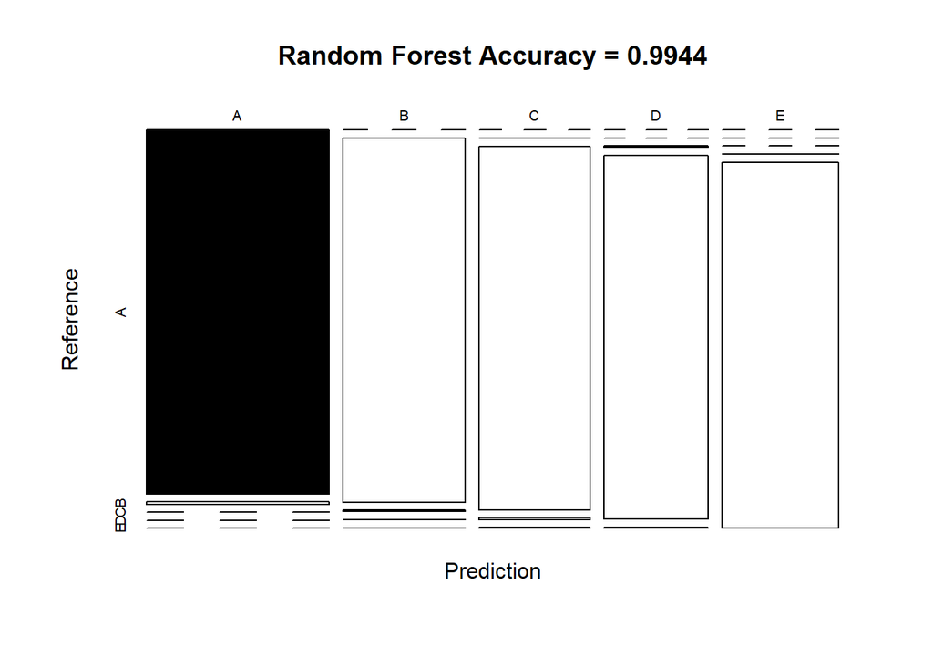

```r
plot(confMatRandForest$table, col = confMatRandForest$byClass,
     main = paste("Random Forest Accuracy =",
                  round(confMatRandForest$overall['Accuracy'], 4)))
```

## 5.2. Decision Tree

### 5.2.1. Decision Tree: Building Model

```r
library(rpart)
modFitDecisionTree <- rpart(classe ~ ., data=trainSet, method="class")
library(rattle)
```

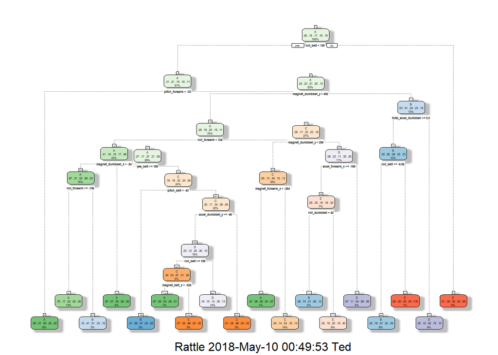

```r
fancyRpartPlot(modFitDecisionTree)
```

### 5.2.2. Decision Tree: Testing for Accuracy

```r
predictDecisionTree <- predict(modFitDecisionTree, testSet, type="class")
confMatDecisionTree <- confusionMatrix(predictDecisionTree, testSet$classe)
confMatDecisionTree
```

```
## Confusion Matrix and Statistics
##
##           Reference
## Prediction    A    B    C    D    E
##          A 1364  169   24   48   16
##          B   60  581   46   79   74
##          C   52  137  765  129  145
##          D  183  194  125  650  159
##          E   15   58   66   58  688
##
## Overall Statistics
##
##                Accuracy : 0.6879
##                  95% CI : (0.6758, 0.6997)
##     No Information Rate : 0.2845
##     P-Value [Acc > NIR] : < 2.2e-16
##
##                   Kappa : 0.6066
##  Mcnemar's Test P-Value : < 2.2e-16
##
## Statistics by Class:
##
##                      Class: A Class: B Class: C Class: D Class: E
## Sensitivity            0.8148  0.51010   0.7456   0.6743   0.6359
## Specificity            0.9390  0.94543   0.9047   0.8657   0.9590
## Pos Pred Value         0.8415  0.69167   0.6230   0.4958   0.7774
## Neg Pred Value         0.9273  0.88940   0.9440   0.9314   0.9212
## Prevalence             0.2845  0.19354   0.1743   0.1638   0.1839
## Detection Rate         0.2318  0.09873   0.1300   0.1105   0.1169
## Detection Prevalence   0.2754  0.14274   0.2087   0.2228   0.1504
## Balanced Accuracy      0.8769  0.72776   0.8252   0.7700   0.7974
```

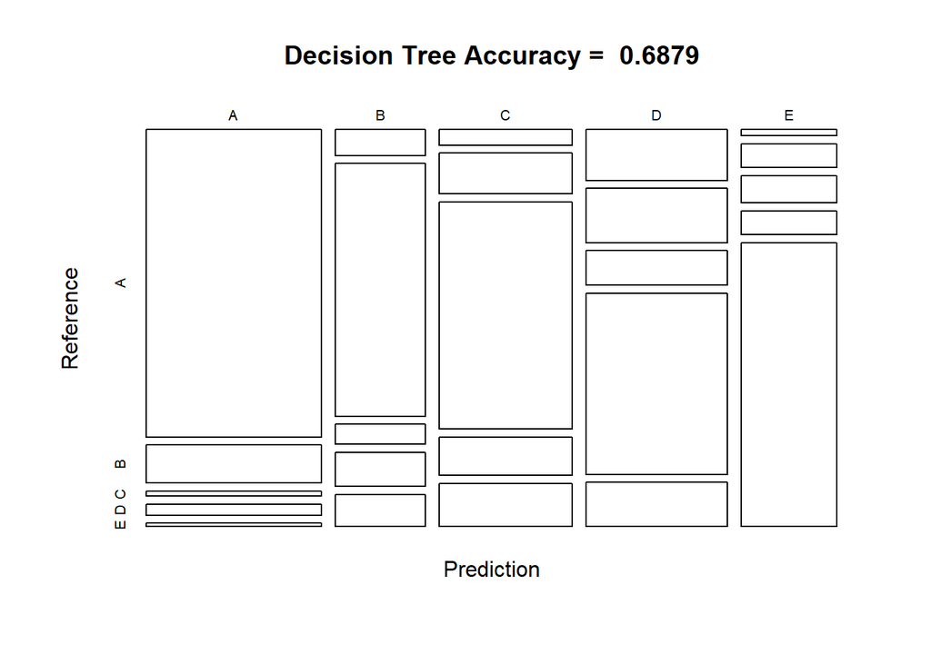

```r
plot(confMatDecisionTree$table, col = confMatDecisionTree$byClass,
     main = paste("Decision Tree Accuracy = ",
                  round(confMatDecisionTree$overall['Accuracy'], 4)))
```

## 5.3. Generalized Boosted Model

### 5.3.1. Generalized Boosted Model: Building Model

```r
set.seed(1234)
controlRF <- trainControl(method="cv", number=3, verboseIter=FALSE)
modFitGBM <- train(classe ~ ., data=trainSet, method="gbm",
                          trControl=controlRF)
modFitRandForest$finalModel
```

[output not shown]

### 5.3.2. Generalized Boosted Model: Testing for Accuracy

```r
# plot matrix results
predictGBM <- predict(modFitGBM, newdata=testSet)
confMatGBM <- confusionMatrix(predictGBM, testSet$classe)
confMatGBM
```

```
## Confusion Matrix and Statistics
##
##           Reference
## Prediction    A    B    C    D    E
##          A 1654   45    0    0    1
##          B   11 1073   33    7   11
##          C    4   18  976   21   12
##          D    4    3   13  928   14
##          E    1    0    4    8 1044
##
## Overall Statistics
##
##                Accuracy : 0.9643
##                  95% CI : (0.9593, 0.9689)
##     No Information Rate : 0.2845
##     P-Value [Acc > NIR] : < 2.2e-16
##
##                   Kappa : 0.9548
##  Mcnemar's Test P-Value : 6.914e-08
##
## Statistics by Class:
##
##                      Class: A Class: B Class: C Class: D Class: E
## Sensitivity            0.9881   0.9421   0.9513   0.9627   0.9649
## Specificity            0.9891   0.9869   0.9887   0.9931   0.9973
## Pos Pred Value         0.9729   0.9454   0.9467   0.9647   0.9877
## Neg Pred Value         0.9952   0.9861   0.9897   0.9927   0.9921
## Prevalence             0.2845   0.1935   0.1743   0.1638   0.1839
## Detection Rate         0.2811   0.1823   0.1658   0.1577   0.1774
## Detection Prevalence   0.2889   0.1929   0.1752   0.1635   0.1796
## Balanced Accuracy      0.9886   0.9645   0.9700   0.9779   0.9811
```

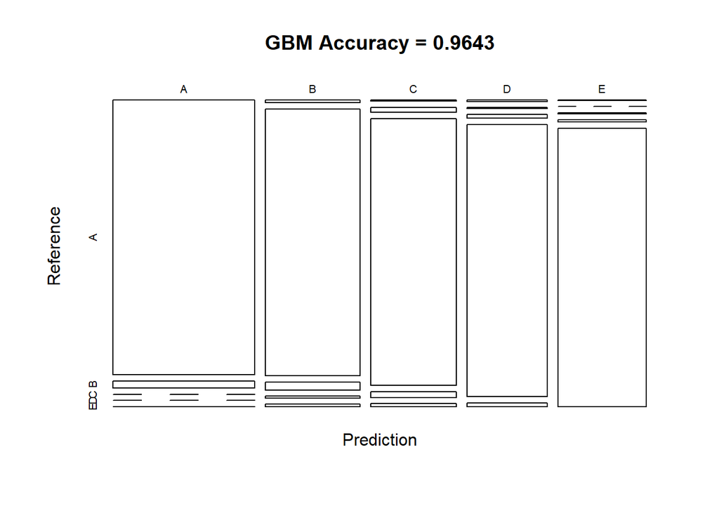

```r
plot(confMatGBM$table, col = confMatGBM$byClass,
     main = paste("GBM Accuracy =",
                  round(confMatGBM$overall['Accuracy'], 4)))
```

# Conclusion

Therefore we can see that Random Forest model has the highest accuracy.

When we apply this model to the TEST data:

```r
testingPrediction <- predict(modFitRandForest, testing)
testingPrediction
```

```
##  [1] B A B A A E D B A A B C B A E E A B B B
## Levels: A B C D E
```

The result shows 100% accuracy in the Coursera Quiz.